# Практика 1

## Математическое моделирование

### Оценка точности модели с непрерывной зависимой переменной

В практических примерах ниже показано:

- как делить данные на выборки (обучающую и тестовую);
- как считать MSE: среднеквадратическую ошибку модели;
- как меняются MSE на тестовой и обучающей выборках с изменением гибкости (числа степеней свободы) модели.

*Модели*: сглаживающие сплайны.  
*Данные*: сгенерированные.

Рассмотрим пример из лекции: как меняется поведение ошибок на тестовой и обучающей выборках при различном числе степеней свободы, если функция зависимости отклика $Y$ от единственного признака $X$ известна. Сгенерируем $X$ и $Y$:

- $X \sim U(5, 105)$
- $Y = f(X) + \epsilon$, где $f(X) = 4 - 0.02X + 0.0055X^2 - 4.9 \cdot 10^{-5} \cdot X^3$; $\epsilon \sim N(0, 1)$.

```r
#  Генерируем данные ###########################################################

my.seed <- 1486372882    # ядро
n.all <- 60              # наблюдений всего
train.percent <- 0.85    # доля обучающей выборки
res.sd <- 1              # стандартное отклонение случайного шума
x.min <- 5               # границы изменения X: нижняя
x.max <- 105             #  и верхняя

# фактические значения x
set.seed(my.seed)
x <- runif(x.min, x.max, n = n.all)

# случайный шум
set.seed(my.seed)
res <- rnorm(mean = 0, sd = res.sd, n = n.all)

# отбираем наблюдения в обучающую выборку
set.seed(my.seed)
inTrain <- sample(seq_along(x), size = train.percent*n.all)

# истинная функция взаимосвязи
y.func <- function(x) {4 - 2e-02*x + 5.5e-03*x^2 - 4.9e-05*x^3}

# для графика истинной взаимосвязи
x.line <- seq(x.min, x.max, length = n.all)
y.line <- y.func(x.line)

# фактические значения y (с шумом)
y <- y.func(x) + res

# Создаём векторы с данными для построения графиков ############################

# наблюдения на обучающей выборке
x.train <- x[inTrain]
y.train <- y[inTrain]

# наблюдения на тестовой выборке
x.test <- x[-inTrain]
y.test <- y[-inTrain]
```

Изобразим исходные данные на графике.

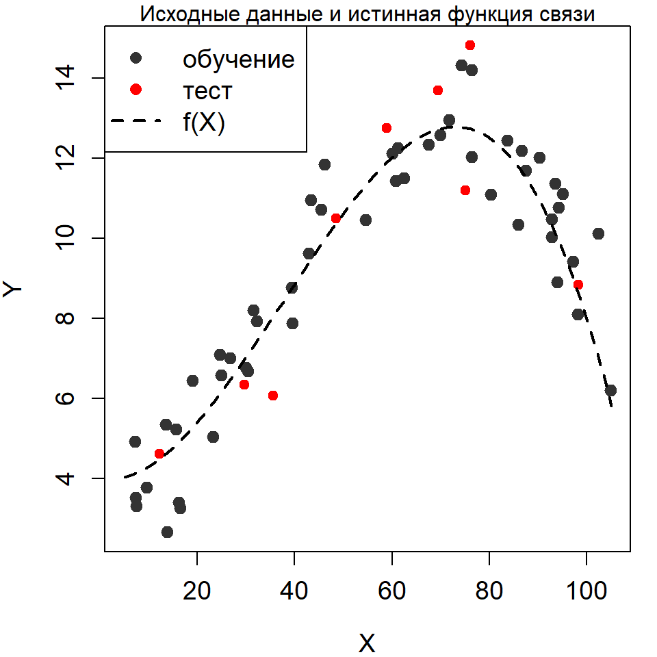

```r
#  График 1: Исходные данные на график #########################################

# убираем широкие поля рисунка
par(mar = c(4, 4, 1, 1))

# наименьшие/наибольшие значения по осям
x.lim <- c(x.min, x.max)
y.lim <- c(min(y), max(y))

# наблюдения с шумом (обучающая выборка)
plot(x.train, y.train,
     col = grey(0.2), bg = grey(0.2), pch = 21,
     xlab = 'X', ylab = 'Y',
     xlim = x.lim, ylim = y.lim,
     cex = 1.2, cex.lab = 1.2, cex.axis = 1.2)

# заголовок
mtext('Исходные данные и истинная функция связи', side = 3)

# наблюдения тестовой выборки
points(x.test, y.test, col = 'red', bg = 'red', pch = 21)

# истинная функция
lines(x.line, y.line, lwd = 2, lty = 2)

# легенда
legend('topleft', legend = c('обучение', 'тест', 'f(X)'),
       pch = c(16, 16, NA),
       col = c(grey(0.2), 'red', 'black'),
       lty = c(0, 0, 2), lwd = c(1, 1, 2), cex = 1.2)
```

В качестве модели используем сплайны со степенями свободы от 2 (прямая) до 40 (количество узлов равно 2/3 наблюдений). Строим модели с различным количеством степеней свободы и в каждом случае считаем среднеквадратическую ошибку модели на обучающей и тестовой выборках.

```r
#  Строим модель №2 из лекции (df = 6) #########################################

# модель 2 (сплайн с df = 6)
mod <- smooth.spline(x = x.train, y = y.train, df = 6)

# модельные значения для расчёта ошибок
y.model.train <- predict(mod, data.frame(x = x.train))$y[, 1]
y.model.test <- predict(mod, data.frame(x = x.test))$y[, 1]

# считаем средний квадрат ошибки на обечающей и тестовой выборке
MSE <- c(sum((y.train - y.model.train)^2) / length(x.train),
         sum((y.test - y.model.test)^2) / length(x.test))
names(MSE) <- c('train', 'test')
round(MSE, 2)
```

```
## train  test
##  0.87  1.71
```

```r
#  Теперь строим модели с df от 2 до 40 ########################################

# максимальное число степеней свободы для модели сплайна
max.df <- 40

tbl <- data.frame(df = 2:max.df)   # таблица для записи ошибок
tbl$MSE.train <- 0                 # столбец: ошибки на обучающей выборке
tbl$MSE.test <- 0                  # столбец: ошибки на тестовой выборке

# цикл по степеням свободы
for (i in 2:max.df) {
    # строим модель
    mod <- smooth.spline(x = x.train, y = y.train, df = i)

    # модельные значения для расчёта ошибок
    y.model.train <- predict(mod, data.frame(x = x.train))$y[, 1]
    y.model.test <- predict(mod, data.frame(x = x.test))$y[, 1]

    # считаем средний квадрат ошибки на обечающей и тестовой выборке
    MSE <- c(sum((y.train - y.model.train)^2) / length(x.train),
             sum((y.test - y.model.test)^2) / length(x.test))

    # записываем ошибки в модель
    tbl[tbl$df == i, c('MSE.train', 'MSE.test')] <- MSE
}

# первые строки таблицы
head(tbl)
```

|  | df | MSE.train | MSE.test |
| --- | --- | --- | --- |
| 1 | 2 | 4.5870148 | 6.905570 |
| 2 | 3 | 1.5520167 | 3.082715 |
| 3 | 4 | 1.0173644 | 2.072195 |
| 4 | 5 | 0.9114617 | 1.781551 |
| 5 | 6 | 0.8707958 | 1.713603 |
| 6 | 7 | 0.8428923 | 1.705567 |

Изобразим на графике поведение ошибок при различном количестве степеней свободы.

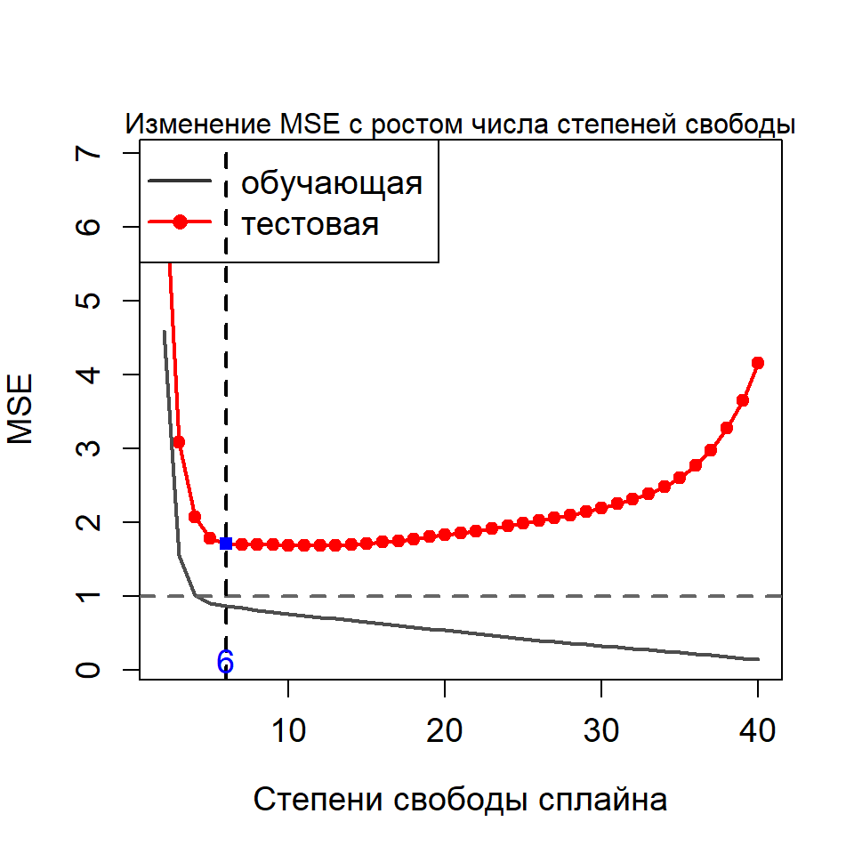

```r
#  График 2: Зависимость MSE от гибкости модели ################################

plot(x = tbl$df, y = tbl$MSE.test,
     type = 'l', col = 'red', lwd = 2,
     xlab = 'Степени свободы сплайна', ylab = 'MSE',
     ylim = c(min(tbl$MSE.train, tbl$MSE.test),
              max(tbl$MSE.train, tbl$MSE.test)),
     cex = 1.2, cex.lab = 1.2, cex.axis = 1.2)

# заголовок
mtext('Изменение MSE с ростом числа степеней свободы', side = 3)

points(x = tbl$df, y = tbl$MSE.test,
       pch = 21, col = 'red', bg = 'red')
lines(x = tbl$df, y = tbl$MSE.train, col = grey(0.3), lwd = 2)
# неустранимая ошибка
abline(h = res.sd, lty = 2, col = grey(0.4), lwd = 2)

# легенда
legend('topleft', legend = c('обучающая', 'тестовая'),
       pch = c(NA, 16),
       col = c(grey(0.2), 'red'),
       lty = c(1, 1), lwd = c(2, 2), cex = 1.2)

# степени свободы у наименьшей ошибки на тестовой выборке
min.MSE.test <- min(tbl$MSE.test)
df.min.MSE.test <- tbl[tbl$MSE.test == min.MSE.test, 'df']

# компромисс между точностью и простотой модели по графику
df.my.MSE.test <- 6
my.MSE.test <- tbl[tbl$df == df.my.MSE.test, 'MSE.test']

# ставим точку на графике
abline(v = df.my.MSE.test,
       lty = 2, lwd = 2)
points(x = df.my.MSE.test, y = my.MSE.test,
       pch = 15, col = 'blue')
mtext(df.my.MSE.test,
      side = 1, line = -1, at = df.my.MSE.test, col = 'blue', cex = 1.2)
```

На этом графике:

- При движении слева направо MSE на обучающей выборке (серая кривая) сокращается, потому что с ростом числа степеней свободы расчёт число узлов, по которым строится сплайн. При этом модельная кривая подгоняется по всё возрастающему количеству точек и становится всё более гибкой. В результате индивидуальные расстояния от фактических наблюдений за $Y$ до их модельных оценок сокращаются, что приводит к сокращению MSE.
- При движении слева направо MSE на тестовой выборке (красная кривая) сначала резко сокращается, затем растёт. Нам известна истинная форма связи $Y$ с $X$, она описывается кубической функцией. Число степеней свободы такой модели равно числу оцениваемых параметров, т.е. 4 (коэффициенты перед $X$, $X^2$, $X^3$ и константа). Поэтому резкое падение ошибки на тестовой выборке при небольшом числе степеней свободы связано с тем, что модель приближается по гибкости к истинной функции связи. Затем MSE на тестовой выборке довольно долго остаётся стабильной, а затем начинает расти. Этот рост объясняется эффектом переобучения модели: она всё лучше описывает обучающую выборку, и при этом постепенно становится неприменимой ни к одному другому набору наблюдений.

График с моделью, выбранной в качестве лучшей, показан на рисунке ниже.

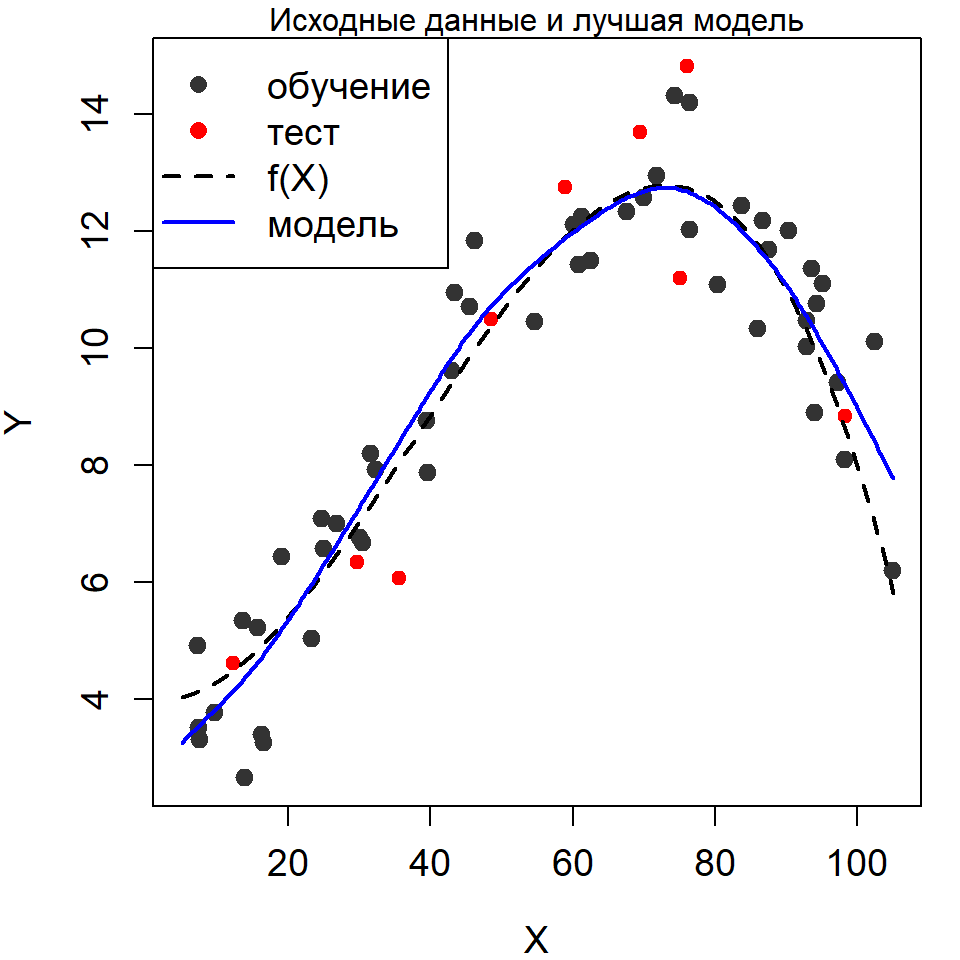

```r
#  График 3: Лучшая модель (компромисс между гибкостью и точностью) ############

mod.MSE.test <- smooth.spline(x = x.train, y = y.train, df = df.my.MSE.test)

# для гладких графиков модели
x.model.plot <- seq(x.min, x.max, length = 250)
y.model.plot <- predict(mod.MSE.test, data.frame(x = x.model.plot))$y[, 1]

# убираем широкие поля рисунка
par(mar = c(4, 4, 1, 1))

# наименьшие/наибольшие значения по осям
x.lim <- c(x.min, x.max)
y.lim <- c(min(y), max(y))

# наблюдения с шумом (обучающая выборка)
plot(x.train, y.train,
     col = grey(0.2), bg = grey(0.2), pch = 21,
     xlab = 'X', ylab = 'Y',
     xlim = x.lim, ylim = y.lim,
     cex = 1.2, cex.lab = 1.2, cex.axis = 1.2)

# заголовок
mtext('Исходные данные и лучшая модель', side = 3)

# наблюдения тестовой выборки
points(x.test, y.test,
       col = 'red', bg = 'red', pch = 21)

# истинная функция
lines(x.line, y.line,
      lwd = 2, lty = 2)

# модель
lines(x.model.plot, y.model.plot,
      lwd = 2, col = 'blue')

# легенда
legend('topleft', legend = c('обучение', 'тест', 'f(X)', 'модель'),
       pch = c(16, 16, NA, NA),
       col = c(grey(0.2), 'red', 'black', 'blue'),
       lty = c(0, 0, 2, 1), lwd = c(1, 1, 2, 2), cex = 1.2)
```

## Упражнение 1

1. Завести аккаунт на github.com.
2. **Задача 1.** На данных своего варианта повторить три графика из первой практики, выбрав число степеней свободы как компромисс между точностью (оценкой ошибки на тестовой выборке) и простотой модели (числом степеней свободы). Все рисунки сохранить в графические файлы в формате png.
3. **Задача 2.** Решить задачу 1, изменив характеристики данных (см. свой вариант). Сравнить с задачей 1, объяснить различия в величине MSE. Все рисунки сохранить в графические файлы в формате png.
4. Выполненные задачи 1-2 разместить в одном отчёте в репозитории на github.com, выслать ссылку на него на почту преподавателя. В репозитории должны лежать:
- файл README.md с кратким описанием содержимого репозитория;
- скрипт генерации отчёта: файл .Rmd в кодировке UTF-8;
- графики, сгенерированные в задании.

В отчёте с решением должны присутствовать, кроме блоков кода R, вводный текст с постановкой задачи и анализ динамики MSE на тестовой и обучающей выборках в вашем варианте.

## Варианты

Все условия, не упомянутые в таблице (величина выборки, закон распределения $X$ и т.д.) брать из первой практики.

| Номер варианта | Функция для задачи 1 | Характеристики для задачи 2 |
| --- | --- | --- |
| 1 | $f(X) = 8 + 3.5 \cdot \sin{\Big ( {x - 30 \over 9 } \Big )}$ | $n = 600$ |
| 2 | $f(X) = 15 + 0.02 \cdot x -0.005 \cdot (x - 45)^2 + 0.00006 \cdot (x - 54)^3$ | $train.percent = 0.9$ |
| 3 | $f(X) = 12 - 0.05 \cdot x$ | $res.sd = 2$ |
| 4 | $f(X) = 8 + 3.5 \cdot \sin{\Big ( {x - 30 \over 9 } \Big )}$ | $train.percent = 0.3$ |
| 5 | $f(X) = 15 + 0.02 \cdot x -0.005 \cdot (x - 45)^2 + 0.00006 \cdot (x - 54)^3$ | $res.sd = 0.5$ |
| 6 | $f(X) = 12 - 0.05 \cdot x$ | $n = 300$ |
| 7 | $f(X) = 8 + 3.5 \cdot \sin{\Big ( {x - 30 \over 9 } \Big )}$ | $res.sd = 1.5$ |
| 8 | $f(X) = 15 + 0.02 \cdot x -0.005 \cdot (x - 45)^2 + 0.00006 \cdot (x - 54)^3$ | $n = 500$ |
| 9 | $f(X) = 12 - 0.05 \cdot x$ | $train.percent = 0.5$ |
| 10 | $f(X) = 8 + 3.5 \cdot \cos{\Big ( {x - 30 \over 12 } \Big )}$ | $n = 600$ |
| 11 | $f(X) = 25 + 0.02 \cdot x -0.004 \cdot (x - 45)^2 + 0.00006 \cdot (x - 54)^3$ | $train.percent = 0.9$ |
| 12 | $f(X) = 12 - 0.1 \cdot x$ | $res.sd = 2.5$ |

*Источники*

1. *James G., Witten D., Hastie T. and Tibshirani R.* An Introduction to Statistical Learning with Applications in R. URL: http://www-bcf.usc.edu/~gareth/ISL/ISLR%20First%20Printing.pdf